# Nitrification, denitrification and N<sub>2</sub>O emissions in STICS

Joel Leonard

13 November 2016 (updated 27 September 2018)

The STICS model simulates nitrification, denitrification and the associated N2O emissions. The use of the default options and settings should allow to obtain reasonable results and is the first thing to try before changing any option or setting.

To simulate N2O emissions, both nitrification and denitrification options must be activated. This activation is done in the soil file (`sols.xml`) and for each soil, via the parameters `codenitrif` and `codedenit`. Two parameters must also be entered at the same place where denitrification is activated: `profdenit` and `vpotdenit` (see list of parameters and description of formalisms below).

The rest of the configuration is done in the general parameter file `param_gen.xml`, under the heading “Nitrification, denitrification and associated N2O emissions”.

# 1 Options, variables, parameters

## 1.1 Choice of options

The following table summarizes the available options, whose formalisms and parameters will then be detailed later in the document. Some parameters must be entered at the same place where the option is activated.

| Option | Parameter | Default value | Description |
| --- | --- | --- | --- |
| Nitrification rate dependence on NH4 | `code_vnit` | **1** | **1** = the nitrification rate is proportional to NH4 concentration ; **2** = the nitrification rate depends on NH4 concentration according to a Michaelis-Menten function (saturation) |
| Temperature function for nitrification | `code_tnit` | **2** | **1** = piecewise linear function ; **2** = gaussian function |
| Nitrification N20 ratio | `code_rationit` | **2** | **1** = constant ratio (parameter) ; **2** = variable ratio according to soil water filled pore space (WFPS) |
| Hourly WFPS calculation for nitrification | `code_hourly_wfps_nit` | **1** | **1** = calculation of the hourly evolution of soil WFPS for days with rainfall ; **2** = option disabled |
| Denitrification potential | `code_pdenit` | **1** | **1** = constant potential (parameter) ; **2** = potential estimated from soil organic C content |
| Denitrification N20 ratio | `code_ratiodenit` | **2** | **1** = constant ratio (parameter) ; **2** = variable ratio according to pH, soil WFPS, NO3 concentration |
| Hourly WFPS calculation for denitrification | `code_hourly_wfps_denit` | **1** | **1** = calculation of the hourly evolution of soil WFPS for days with rainfall ; **2** = option disabled |

It is highly recommended to keep these option choices and the default parameters as a first step. As a second step, changing the denitrification potential (`vpotdenit` in the soil parameter file `sol.xml`), which can be optimized or fixed according to the available knowledge, deserves to be explored.

## 1.2 Input and output variables of the N2O submodel (to be completed)

| Type | List |
| --- | --- |
| Input variables which are used in the calculations but are not updated by the N2O model | precip, tsol, hur |
| Input variables used in the calculations and updated by the N2O model | amm, nit |
| Input variables only updated by the model | Qnitrif, Qem_N2Onit, QNdenit, Qem_N2Oden |
| Output variables | nitrifj, Ndenit, em_N2Onit, em_N2Oden |

## 1.3 Parameters

The parameters specific to the nitrification, denitrification and N2O emissions STICS submodel are listed in the following table, with their default values.

| Parameter | Default value | Unit | Description | File |
| --- | --- | --- | --- | --- |
| `hminn` | 0.30 | . | fraction of the soil water content at field capacity below which the nitrification is zero | `param_gen.xml` |
| `hoptn` | 0.90 | . | fraction of the soil water content at field capacity above which nitrification is optimal | `param_gen.xml` |
| `pHminnit` | 4.0 | . | pH below which nitrification is zero | `param_gen.xml` |
| `pHmaxnit` | 7.2 | . | pH above which nitrification is optimal | `param_gen.xml` |
| `nh4_min` | 1.0 | mg NH4-N/kg soil | minimum soil ammonium content (fixed ammonium, not available for nitrification) | `param_gen.xml` |
| `pHminden` | 5.6 | . | pH below which denitrification only produces N2O (for a soil WFPS of ~80%) | `param_gen.xml` |
| `pHmaxden` | 9.2 | . | pH above which denitrification only produces N2 (for a soil WFPS of ~80%) | `param_gen.xml` |
| `wfpsc` | 0.62 | . | soil WFPS threshold beyond which denitrification is active, and more generally beyond which anaerobic conditions become significant | `param_gen.xml` |
| `tdenitopt_gauss` | 47 | °C | optimum temperature for denitrification | `param_gen.xml` |
| `scale_tdenitopt` | 25 | °C | parameter controlling the range of temperature favourable to denitrification | `param_gen.xml` |
| `Kd` | 148 | mg NO3-N/L | half saturation constant for the function relating the NO3 concentration to the denitrification rate. Multiplying by gravimetric soil water content yields mg NO3-N/kg soil | `param_gen.xml` |
| `k_desat` | 3.0 | 1/day | constant controlling the rate of desaturation of a soil layer (Hourly WFPS option enabled). A value of 3.0 allows 95% of the water to be drained in one day and thus to reach a soil water content very … | `param_gen.xml` |
| `fnx` | 0.80 | 1/day | potential nitrification rate expressed as the fraction of available ammonium nitrified in one day (linear option for nitrification rate) | `param_gen.xml` |
| `vnitmax` | 27.3 | mg NH4-N/kg soil/day | nitrification potential (Michaelis-Menten option for nitrification rate) | `param_gen.xml` |
| `Kamm` | 24 | mg NH4-N/L | half saturation constant for the function relating NH4 concentration to nitrification rate (Michaelis-Menten option for nitrification rate). Multiplying by gravimetric soil water content yields mg NH4… | `param_gen.xml` |
| `tnitmin` | 5 | °C | temperature below which nitrification is zero (option piecewise linear function) | `param_gen.xml` |
| `tnitopt` | 30 | °C | temperature above which nitrification is optimal (option piecewise linear function) | `param_gen.xml` |
| `tnitop2` | 35 | °C | temperature above which nitrification begins to decrease after the optimum (option piecewise linear function) | `param_gen.xml` |
| `tnitmax` | 58 | °C | temperature above which nitrification is zero (option piecewise linear function) | `param_gen.xml` |
| `tnitopt_gauss` | 32.5 | °C | optimum temperature for nitrification (if gaussian function option enabled) | `param_gen.xml` |
| `scale_tnitopt` | 16 | °C | parameter controlling the range of temperature favourable to nitrification (if gaussian function option enabled) | `param_gen.xml` |
| `rationit` | 0.0016 | . | proportion of nitrified nitrogen emitted as N2O (if constant ratio option enabled) | `param_gen.xml` |
| `cmin_pdenit` | 1.0 | % | organic carbon content below which the denitrification potential is minimal (option calculation of the denitrification potential enabled) | `param_gen.xml` |
| `cmax_pdenit` | 6.0 | % | organic carbon content above which the denitrification potential is maximum (option calculation of the denitrification potential enabled) | `param_gen.xml` |
| `min_pdenit` | 1.0 | mg N/kg soil/day | minimum value of denitrification potential (option calculation of denitrification potential enabled) | `param_gen.xml` |
| `max_pdenit` | 20.0 | mg N/kg soil/day | maximum value of denitrification potential (option calculation of denitrification potential enabled) | `param_gen.xml` |
| `ratiodenit` | 0.20 | . | proportion of denitrified nitrogen emitted as N2O (if constant ratio option enabled) | `param_gen.xml` |
| `profdenit` | 20 | cm | maximum soil depth affected by denitrification | `sols.xml` |
| `vpotdenit` | 2.0 | kg N/ha/day | denitrification potential (constant potential option) over soil thickness defined by `profdenit` | `sols.xml` |

# 2 Formalisms

## 2.1 Formalisms for nitrification

Nitrification is calculated over the depth of humification (`profhum` in `sols.xml`). If nitrification is not activated, the ammonium is instantly converted into nitrate.

The nitrification rate is calculated as the product of a potential rate and control factors: substrate availability (NH4) and environmental conditions (pH, temperature, WFPS):

$$vnit = vnitpot \cdot f_{NH_4} \cdot f_{pH} \cdot f_T \cdot f_{WFPS}$$

### 2.1.1 Potential nitrification rate and effect of NH4 concentration

With the linear option (`code_vnit`=1), the nitrification potential rate and the NH4 effect (*fNH4*) are not dissociated. The potential daily nitrification rate is a fixed proportion of the available amount of ammonium:

$$vnitpot = \mathsf{fnx} \cdot (NH_4-\mathsf{nh4\_min})$$
With the Michaelis-Menten option (`code_vnit`=2), the potential nitrification rate provided as input (`vnitmax`) is used and this rate is then modulated by *fNH4*:
$$f_{NH_4} = \frac{(NH_4-\mathsf{nh4\_min})}{(NH_4-\mathsf{nh4\_min}) + (w \cdot \mathsf{Kamm})}$$
where *w* is the gravimetric soil water content. *NH4* is expressed in mg/kg soil. The following figure shows *fNH4* for two `Kamm` values (24 and 202 mg N/L) and two *w* values (0.15 and 0.24).

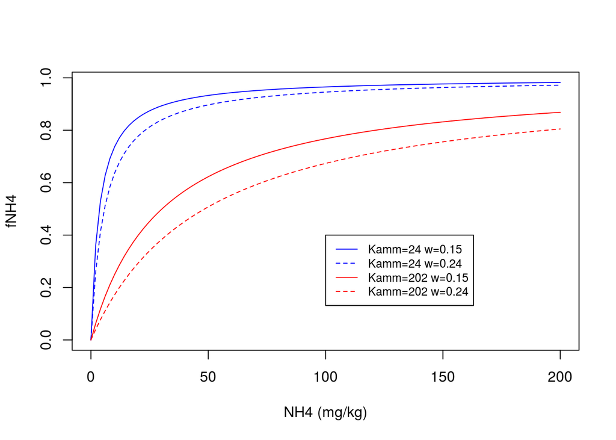

This option should however be avoided. Indeed, during fertilization, the nitrogen supplied is assigned in STICS to the first soil layer. The thickness of this layer being only 1 cm, it results in an artificially very high ammonium concentration. As *fNH4* saturates for high ammonium concentrations, the nitrification rate is maximum but only concerns one cm of soil, which means that total nitrification is greatly underestimated. This effect could be corrected by spreading the contribution over a greater depth, but this would be one more parameter to estimate. The linear approach avoids this difficulty thanks to the absence of a saturation of the nitrification rate that compensates for the small thickness of the soil layer concerned.

### 2.1.2 pH effect

The effect of pH on nitrification is linear between `pHminnit` where nitrification is zero and `pHmaxnit` where nitrification is maximum. The figure below illustrates this relationship with the default values in STICS:

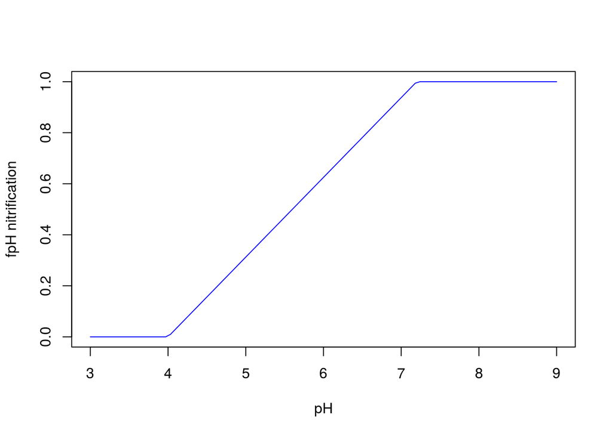

### 2.1.3 Temperature effect

The temperature effect is described either by a piecewise linear model (`code_tnit`=1) or by a gaussian function (`code_tnit`=2). In both cases there is an optimal temperature or temperature range. The gaussian function is less demanding in parameters (2 instead of 4) and it is easier to manipulate the optimum temperature, especially to shift it according to the average temperature for example.

The gaussian function used is as follows:
$$f_T=\exp \left(-{\frac{(t-\mathsf{tnitopt\_gauss})^2}{\mathsf{scale\_tnitopt}^2}}\right)$$

It is illustrated in the figure below along with the piecewise linear function with the default STICS parameters.

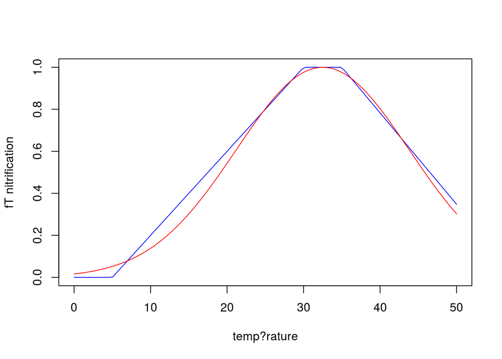

### 2.1.4 Effect of soil water content

The effect of soil water content on nitrification is twofold: nitrification increases with soil water content, but very high soil water contents can lead to anoxia which is unfavourable to nitrification. This effect is described in STICS by a piecewise linear function. Soil moisture thresholds (`hminn`, `hoptn`) are described as a percentage of soil moisture at field capacity. Nitrification is zero below `minn` or when the soil is completely saturated with water. It is optimal between `hoptn` and field capacity. It increases linearly between `hminn` and `hoptn`, and decreases linearly between field capacity and saturation.

The following figure illustrates the effect of soil water content (using WFPS) on nitrification with the default STICS parameters, for a soil where field capacity is 0.24 g/g and for two bulk density values (1.3 and 1.55 g/cm3). For comparison, the function used in Bessou et al. 2010 is also illustrated in dotted lines.

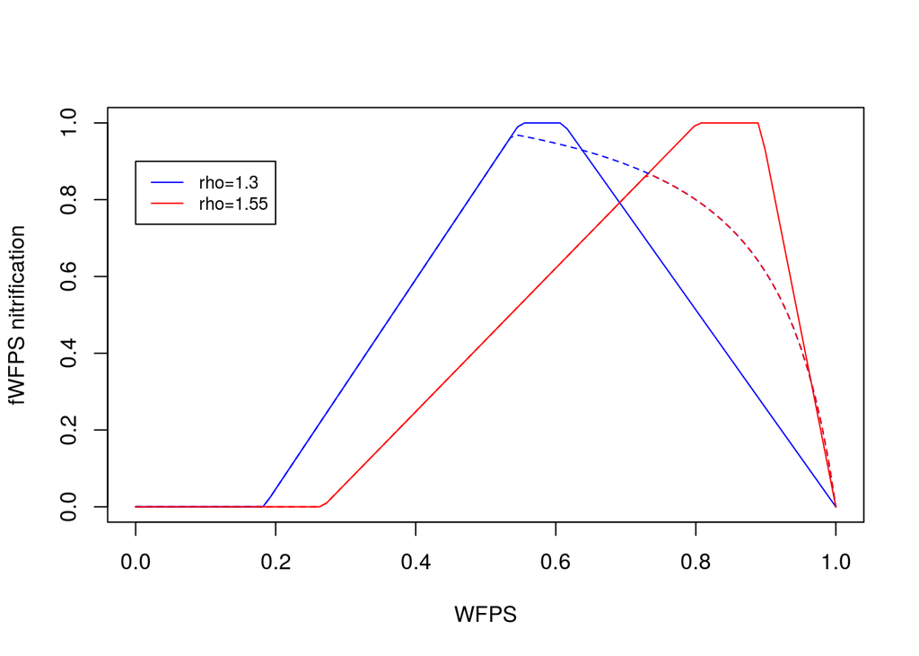

## 2.2 Formalisms for denitrification

Denitrification is calculated over the depth defined by the parameter `profdenit` in `sols.xml`. It is calculated as the product of a potential rate and control factors: substrate availability (NO3) and environmental conditions (temperature, WFPS):

$$vdenit = vdenitpot \cdot f_{NO_3} \cdot f_T \cdot f_{WFPS}$$
There is no pH effect taken into account on denitrification itself, although some work suggests an optimum pH depending on the soil.

### 2.2.1 Denitrification potential

The denitrification potential can either be read from the file `sols.xml` (if `code_pdenit`=1 which is the default, parameter `vpotdenit`) or calculated from soil organic carbon percentage (if `code_pdenit`=2).

The value read from the soil file, `vpotdenit`, is expressed in kg N/ha/day over the depth `profdenit`. This value can be converted to mg/kg/day by dividing by the product of soil bulk density and `profdenit`.

The second option is to estimate the denitrification potential as a function of soil organic carbon percentage (using `norg` and `CsurNsol` in the file `sol.xml`). The proposed function for this is based on the compilation of data from the literature on the relationship between denitrification potential and soil carbon content, but with significant difficulties in comparing the different results due to the diversity of methods and conditions used to characterise the denitrification potential, and strong limits as soil carbon content may not be a good estimate of easily available carbon. This is one part of the model which needs further work and the proposed function should be used with care, if used.  
The denitrification potential (in mg/kg/day for this function!) is minimal for a soil organic carbon percentage less than or equal to `cmin_pdenit` and maximal for a soil organic carbon percentage greater than or equal to `cmax_pdenit`. It increases linearly between the two. The minimum value of the denitrification potential is equal to `min_pdenit` and its maximum value to `max_pdenit`.

The following figure illustrates the relationship between the percentage of organic carbon and denitrification potential (in mg/kg/day!) with the default STICS parameters.

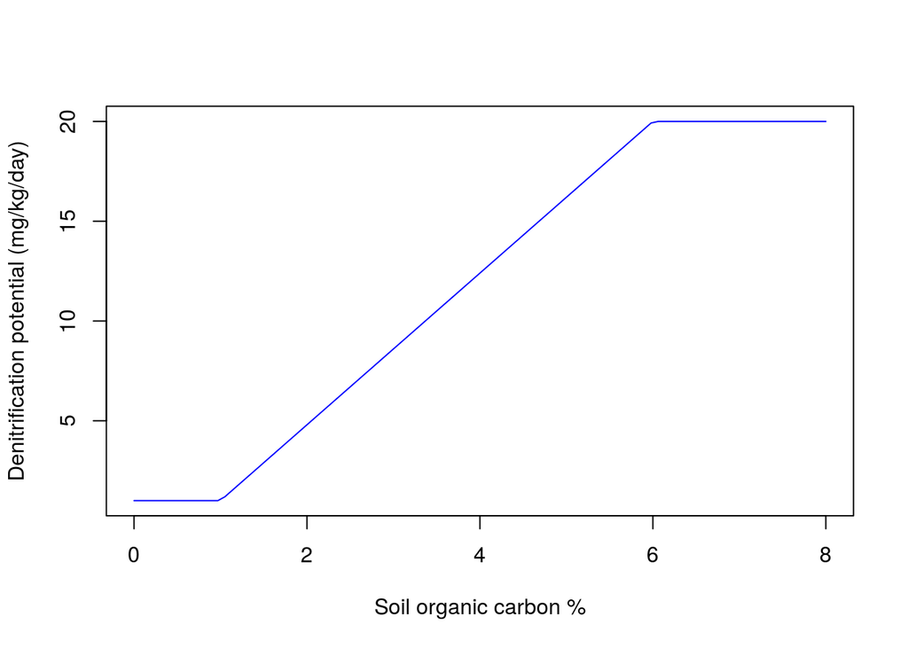

Measured denitrification potential values generally correspond to specific standard conditions. In STICS it is assumed that denitrification potential is measured at 20?C, with a soil nitrate concentration of 200 mg N-NO3/kg soil, without any C addition. Corrections are done in the model to transform the input denitrification potential into a value which is not temperature nor nitrate limited.

### 2.2.2 Effect of nitrate concentration on denitrification

The effect of nitrate concentration on denitrification (*fNO3*) is described by a Michaelis-Menten function.

$$f_{NO_3} = \frac{NO_3}{NO_3 + (w \cdot \mathsf{Kd})}$$
where *w* is the gravimetric soil water content. *NO3* is expressed in mg/kg soil. The following figure shows *fNO3* for `Kd`=148 mg N/L (STICS default value) and for two values of *w* (0.15 and 0.24).

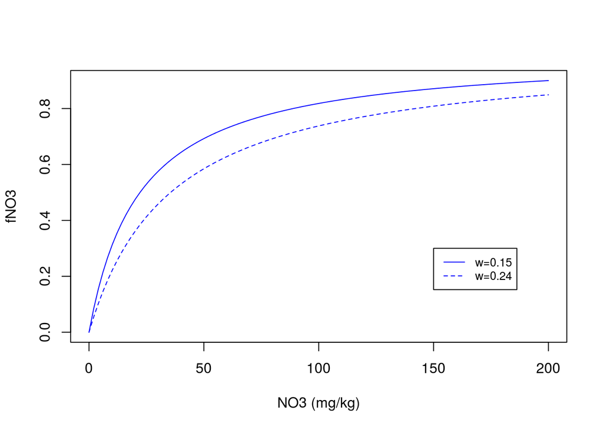

### 2.2.3 Effect of temperature on denitrification

The effect of temperature on denitrification is described by a gaussian function:

$$f_T=\exp \left(-{\frac{(t-\mathsf{tdenitopt\_gauss})^2}{\mathsf{scale\_tdenitopt}^2}}\right)$$

This function is illustrated in the following figure with the default STICS settings.

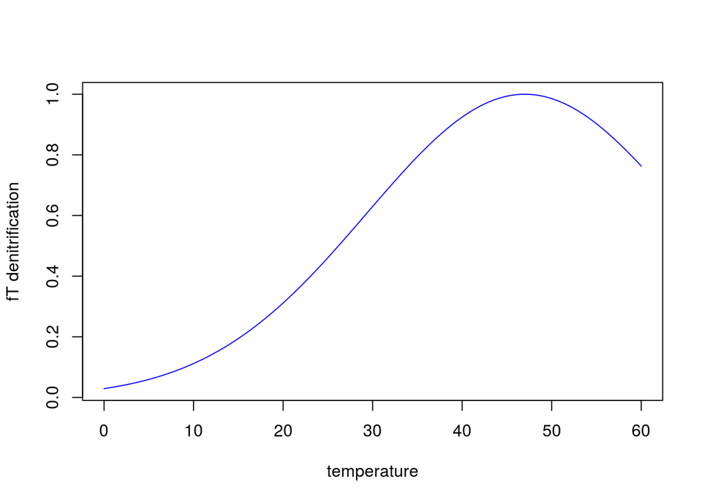

### 2.2.4 Effect of soil water content on denitrification

Denitrification is an anaerobic process. Thus, the higher soil WFPS, the less aerated the soil is and the more active the denitrification is. The intensity of denitrification is described as a function of WFPS via a function combining a threshold above which denitrification is active (`wfpsc`), and a rapid increase of denitrification rate above this threshold:

$$f_{WFPS}=\left(\frac{wfps-\mathsf{wfpsc}}{1-\mathsf{wfpsc}}\right)^{1.74}$$
This function is illustrated below, with the default value of `wfpsc`.

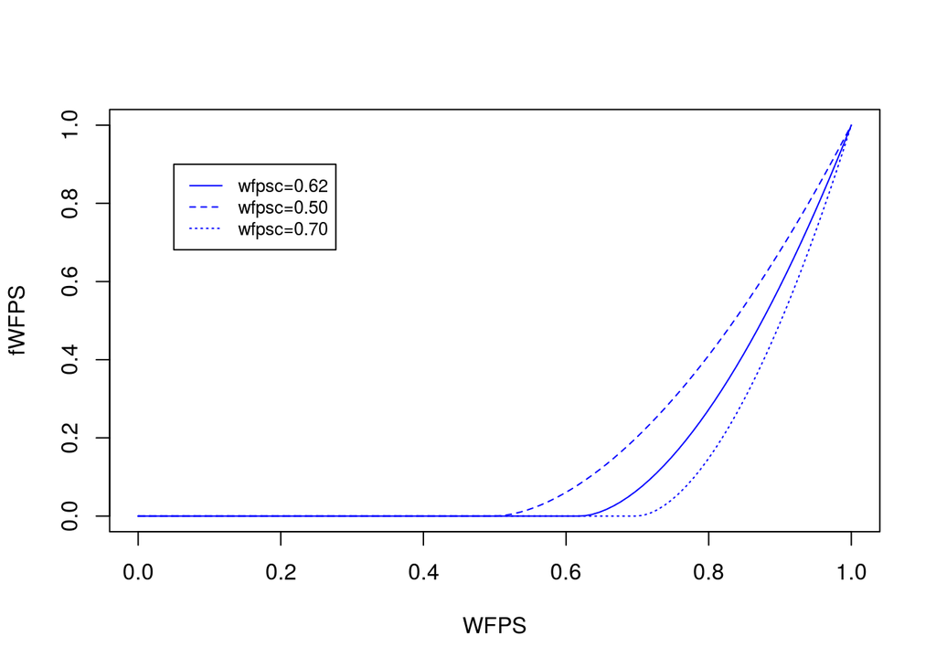

The `wfpsc` threshold depends on soil texture. Some work suggests that it varies from about 0.5 for a coarse texture to 0.7 for a fine texture. There is currently no function linking this threshold to soil texture in STICS.

## 2.3 Formalisms for N2O emissions

The N2O emissions associated with each of the two processes, nitrification and denitrification, are described as a fixed or variable proportion of the nitrification or denitrification rate.

$$N_2O_{nit} = z \cdot vnit \space \mathsf{et} \space N_2O_{denit} = r \cdot vdenit$$

### 2.3.1 Emissions associated to nitrification

If `rationit_code`=1, the fraction *z* of the nitrified nitrogen emitted as N2O is constant and is equal to `rationit`, whose default value is 0.0016 (0.16%).

The default option in STICS is, however, that this *z* fraction varies with soil WFPS:

$$z = 0.16 \cdot \left(\frac{0.40 \cdot WFPS - 1.04}{WFPS - 1.04}\right)$$

As soil WFPS approaches 1, anoxia becomes important in soil and favours losses in the N2O form, as shown in the following figure using the default STICS parameters:

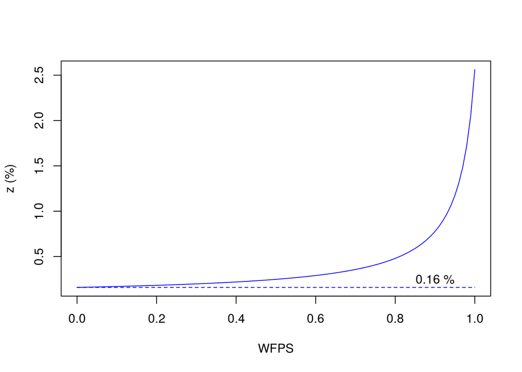

For low WFPS values, the value of *z* is 0.16% (like the default constant value).

### 2.3.2 Emissions associated to denitrification

If `code_ratiodenit`=1, the fraction *r* of denitrified nitrogen emitted as N2O is constant and equal to `ratiodenit`, whose default value is set at 0.20 (20%).

The default option in STICS, however, is that this fraction *r* varies with pH, soil WFPS and nitrate concentration, in decreasing order of importance.

#### 2.3.2.1 pH effect

Soil pH has a very significant effect on the potential to reduce N2O to N2. Very often, reduction is very limited below a pH of 6 and close to its maximum above a pH of 8. The fraction *r* of denitrified nitrogen emitted as N2O is therefore very pH dependent.

The average relationship (obtained from the compilation of data from different studies) between the observed value of *r* and soil pH can be described by a piecewise linear function. This relationship is illustrated in the following figure, with STICS default values for the `pHminden` and `pHmaxden` thresholds.

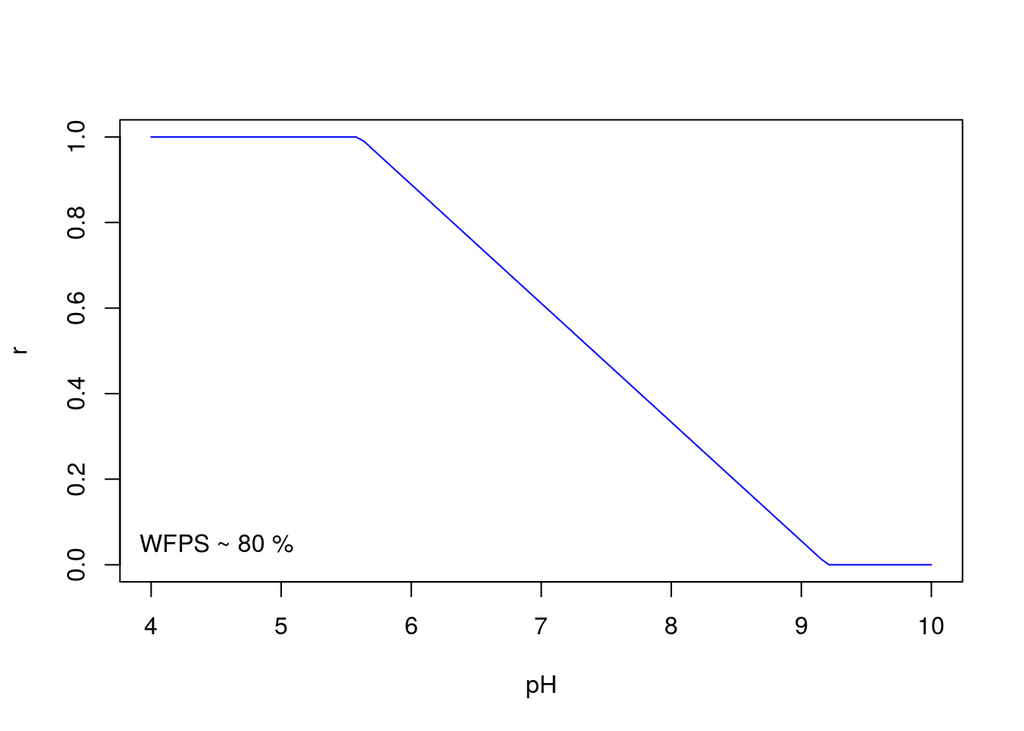

The value of *r* estimated from this function is equal to 1 (denitrification only produces N2O) if the pH is less than `pHminden`, it is zero (denitrification only produces N2) if the pH is greater than `pHmaxden`, it decreases linearly between these two thresholds.

The relationship suggested by the experimental data and illustrated above corresponds to an average WFPS value of ~80% and a high nitrate concentration. The value of *r* calculated as a function of pH should then be modulated as a function of WFPS (used as a proxy for anoxia) and NO3 concentration.

#### 2.3.2.2 WFPS effect

The effect of WFPS on *r* reflects the fact that high soil WFPS correlates with low oxygen availability, which promotes complete denitrification and a small proportion of the denitrified nitrogen emitted as N2O.

For WFPS close to the threshold above which denitrification begins to be active (`wfpsc`), the soil is still well aerated and the reduction of N2O to N2 is minimal, *r* being therefore at its maximum. On the contrary, when the soil is completely saturated with water, the reduction is maximum and the values of *r* then tend towards a minimum. The effect of WFPS on *r* is described in STICS by the following function in which *r* is considered to decrease linearly between WFPS=`wfpsc` and WFPS=1.

$$f_{WFPS} = 1 - \frac{WFPS-\mathsf{wfpsc}}{1-\mathsf{wfpsc}}$$
This function is illustrated in the following figure, with the default STICS parameters. Also shown are the average WFPS corresponding to the previous figure on the relationship between *r* and pH (81.5%) and the relationship used in Bessou et al.

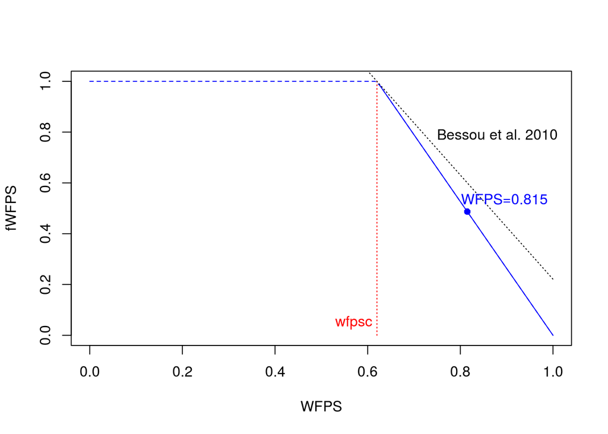

#### 2.3.2.3 Effect of nitrate concentration

The value of *r* is also influenced by nitrate concentration through an inhibition of the reduction of N2O to N2 which increases with nitrate concentration. This effect is represented in STICS by a Michaelis-Menten function (where nitrate concentration is expressed in mg/kg):

$$f_{NO_3} = \frac{NO_3}{NO_3+1}$$
This function is shown below, along with the piecewise linear function used in Bessou et al., 2010 (dotted line). Inhibition is important as soon as nitrate concentration exceeds a few mg/kg. Thus, in most conditions where nitrate levels are not close to zero, this effect is not noticeable.

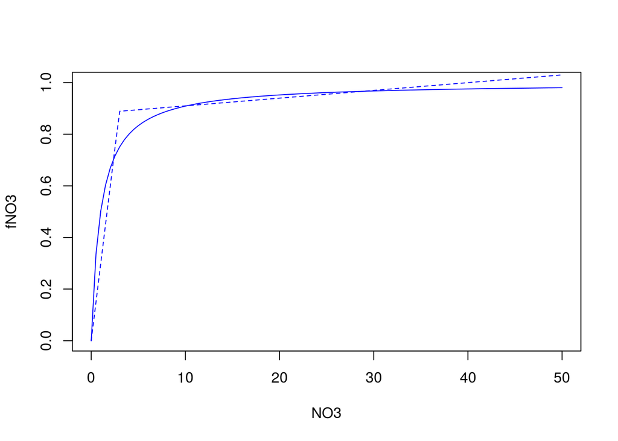

#### 2.3.2.4 Combination of the different effects

A first estimate of *r* is calculated using the pH function, without limiting the value to 0 or 1 (*r<sub>est</sub>*). This value of *r* actually corresponds to a WFPS of 81.5%. It is then corrected to correspond to a WFPS value equal to `wfpsc` (zero WFPS effect):

$$r_{cor} = \frac{r_{est}}{f_{WFPS} \;\; (0.815)}$$
The functions fWFPS and fNO3 are then applied:

$$r = r_{cor} \cdot f_{WFPS} \cdot f_{NO3}$$
and the resulting value of *r* is finally limited to the 0 to 1 interval.

The following figure illustrates the effect of different WFPS and NO3 concentration values on the value of *r* as a function of pH.

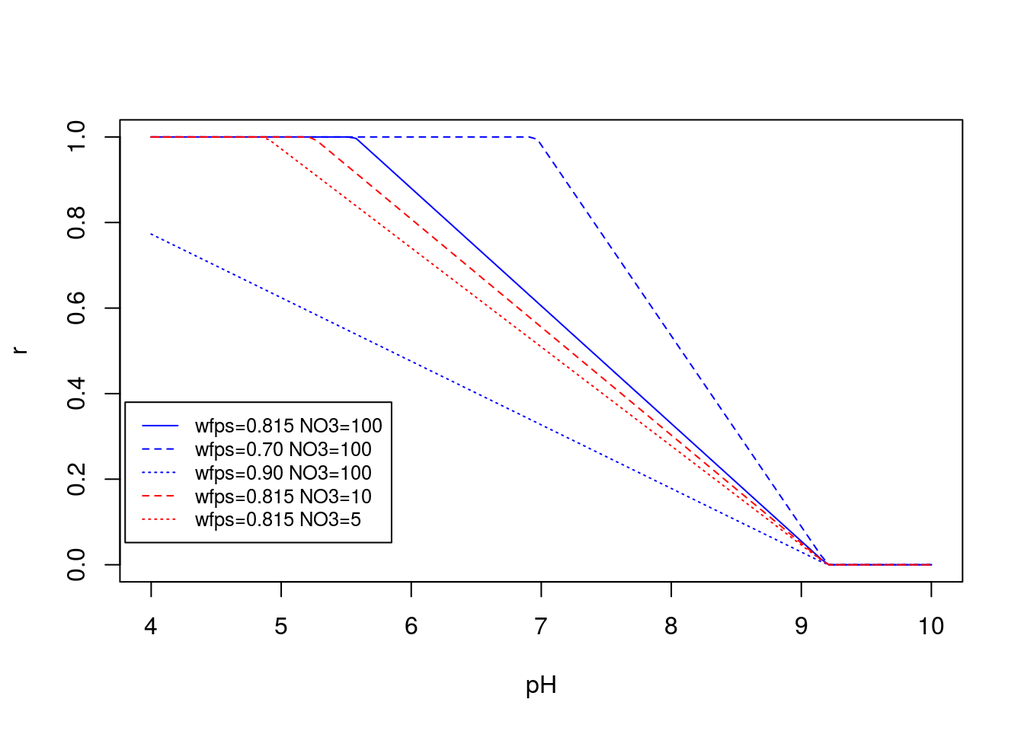

## 2.4 Additional formalisms

### 2.4.1 Hourly WFPS option

Soil WFPS is a key variable for both nitrification, denitrification and associated N2O emissions. However, the STICS model is a daily time step tipping-bucket model where drainage to the underlying soil layers occurs as soon (and only) as field capacity is reached. As a result, without any additional mechanism, the near-saturation soil water content that may temporarily exist near the ground surface during a rainfall or in the hours that follow are not simulated. Moreover, since the soil water content is limited to field capacity which corresponds more or less to the soil water content where anoxia begins to develop, all processes highly dependent on this anoxia are underestimated (inhibition of nitrification, proportion of N2O emitted by nitrification, denitrification, reduction of N2O to N2).

There is an option in STICS called “macro-porosity” which is enabled if `codemacropor` = 1. This option has sometimes been used to simulate soil moisture values beyond field capacity. It activates the `infil` parameters from the `sols.xml` file (one value per soil layer). If infiltrability at the bottom of a soil layer is limiting, excess water accumulates in that layer from the bottom. This option is well suited, for example, to simulate the effect of a low-permeability horizon such as a plough pan. But it corresponds to a very particular type of functioning (saturation from the bottom) which is very different from what happens near the soil surface just after a rain. In addition, as individual 1 cm layers (used for computation) are either saturated (near the bottom) or at field capacity (above), N2O emissions are underestimated because we are either in a situation where denitrification is minimal (field capacity) or in a situation where the reduction of N2O to N2 is maximal (saturation).

Activation of the option `Hourly WFPS calculation for nitrification` (`code_hourly_wfps_nit`=1) and `Hourly WFPS calculation for denitrification` (`code_hourly_wfps_denit`=1) allows to manage soil water contents temporarily higher than field capacity on days with rainfall, and the consequences on the nitrification, denitrification and N2O emissions processes.

If $precip>0$ (day with rain), a wetting front depth is calculated by gradually filling the soil layers from the surface to saturation with the volume of water corresponding to $precip$, the free volume of each layer being $h_{sat}-hur$. For each of the layers saturated in this way, it is assumed that the evolution of soil water content during the day is mainly controlled by drainage, the rate of which is proportional to $h_{sat}-hur$. This results in an exponential evolution of soil water content over time, where `kdesat` is the proportionality coefficient relating the drainage rate to $h_{sat}-hur$ :

$$hur(t) = \mathsf{hucc} + \exp(-\mathsf{kdesat} \cdot t) \cdot (h_{sat}-\mathsf{hucc})$$
The following figure illustrates the evolution of the volumetric water content of a soil layer (with `dacouche`=1.5 g/cm<sup>3</sup>, `hucc`=0.24 g/g) during a day, after initial saturation by rainfall and with the default `kdesat` value (3 days<sup>-1</sup>).

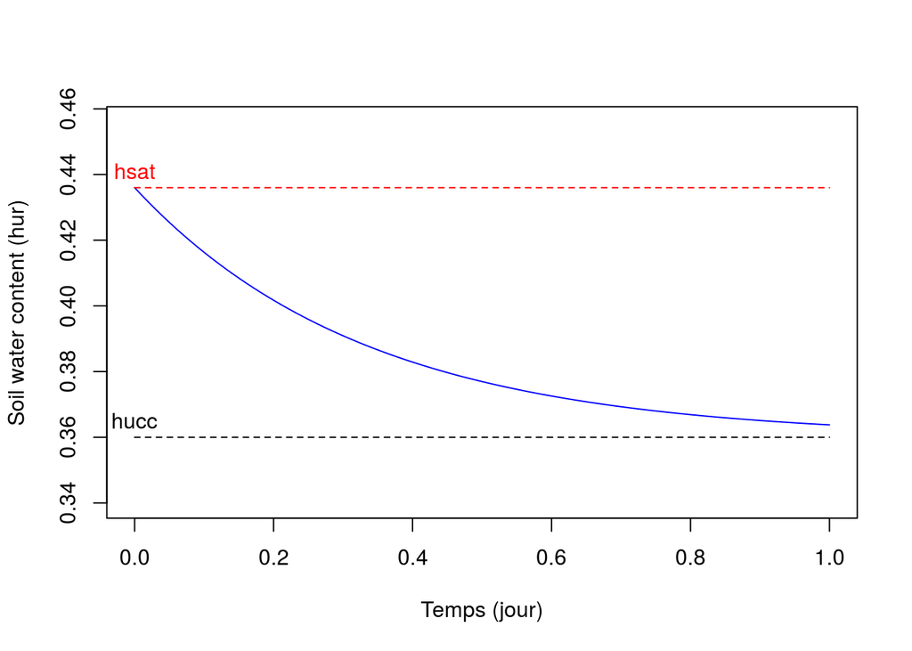

The default value of `kdesat` allows 95% of the water to be drained during one day and thus to reach at the end of the day a value which is very close to field capacity, in line with the daily soil water content calculated by the STICS water transfer submodel.

Each function of soil moisture or WFPS is then integrated from $t=0$ to $t=1$ instead of being applied to the daily soil moisture content, which allows for soil water contents exceeding field capacity to be considered and results for example in a more active denitrification.